# Using MetaCell to define cell-cycle dependent and independent transcriptional heterogeneity

## Create a cell-cycle based KNN graph

Regardless of whether we decided to use all cell-cycle associated geneSet (**“hct116_cellCycle”**, which will be used in this example) or a purified subset of it (**“hct116_cellCycle_narrow”**), we can now create a balanced KNN similarity graph between cells that is based on expression coming from these genes only:

```r
# create gene stats for our expression matrix:
mcell_add_gene_stat(mat_id = 'mat_wt_cellCycle', gstat_id = 'wt_cellCycle_geneStats')
```

```
#> will downsamp
#> done downsamp
#> will gen mat_n
#> done gen mat_n
#> done computing basic gstat, will compute trends
#> ..done
```

```r
# create a list of markers in our expression table (only filtering out very lowly expressed genes or genes that have minimal variance):
mcell_gset_filter_varmean(gset_id="wt_cellCycle_markers", gstat_id="wt_cellCycle_geneStats", T_vm=0.03, force_new=T)
mcell_gset_filter_cov(gset_id = "wt_cellCycle_markers", gstat_id="wt_cellCycle_geneStats", T_tot=20, T_top3=1)


#use marker genes and our expresion table to build a cell-cell similarity graph object:
mcell_add_cgraph_from_mat_bknn(mat_id="mat_wt_cellCycle",
                               gset_id = "wt_cellCycle_markers",
                               graph_id="HCT116_wt_cellCycle_graph",
                               K=100,
                               dsamp=T)
```

```
#> will downsample the matrix, N= 750
#> will build balanced knn graph on 3285 cells and 287 genes, this can be a bit heavy for >20,000 cells
#> sim graph is missing 26 nodes, out of 3285
```

```r
# K: a parameter that defines the initial attempt of the system to assign neighbors for each cell and ultimately can affect the size distribution of derived metacells.
# dsamp: a boolean parameter which indicates whether we want to downsample the expression matrix or not.
```

The last step added to our database a new cell-cell graph object, named *HCT116_wt_cellCycle_graph*. It describes the similarity between all cells in our dataset, based only on the expression of genes in the *“wt_cellCycle_markers”* geneSet.

### Validate our cell-cycle model

However, and before we continue to the randomization step, it is a good practice to perform some sanity checks here - and try to validate that our model is indeed describing cell-cycle as we hoped.

There are many different ways to approach this, but since we are using the MetaCell platform, it makes sense to create metacells that are based on our cell graph, and test whether we can position metacells along a continuum of transcriptional cell-cycle dynamics. Remember that in most cases we may only succeed to model the fraction of cycling ones, which can vary between biological samples (the non-cycling cells might form a big “non-cycling” metacell). In addition, we can expect different distributions of total mRNA content per cell to be one hallmark of our cell-cycle based metacells (but not necessarily, especially if sequencing of libraries is not at saturation or close to it):

```r
# add explanations here
mcell_coclust_from_graph_resamp(
                coc_id="HCT116_wt_cellCycle_coCluster100",
                graph_id="HCT116_wt_cellCycle_graph",
                min_mc_size=50,
                p_resamp=0.75, n_resamp=100)
```

```
#> running bootstrap to generate cocluster
#> 48%...100%
#> done resampling
```

```r
#add explanations here
mcell_mc_from_coclust_balanced(
                coc_id="HCT116_wt_cellCycle_coCluster100",
                mat_id= "mat_wt_cellCycle",
                mc_id= "metaCells_wt_cellCycle",
                K=120, min_mc_size=50, alpha=2)
```

[output not shown]

```r
## We can then generate a 2D model of the formed metacells, and project expression of specific genes along them
```

For more functions and details on plotting metacells, checkout Metacell github repository: https://github.com/tanaylab/metacell

Some examples for plots to test cell cycle model:

[figure not shown]

coloring footprints of a known cell-cycle marker on the 2d metacell projection

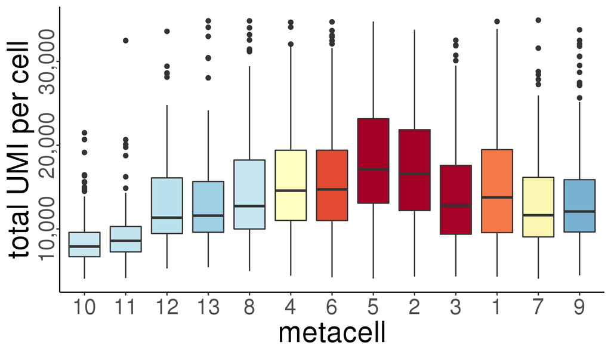

showing distributions of total UMI-per-cell in each of the metacells

If you think that your model looks legit - well done, the longer step of the process is now behind us.

## Find genes that are independent of cell-cycle

Provided with a good estimation for how cells are related to one another based on cell-cycle trends alone, we can now ask which genes are co-variating independently of it.

Specifically, we can take the original expression matrix and shuffle it, where the expression vector of each cell will be randomly sampled from the *K* cells that are most adjacent to it based on our cell-cycle graph:

```r
gene_cors_cellCycle = mcell_cgraph_norm_gcor(cgraph_id = "HCT116_wt_cellCycle_graph",
                            mat_id = "mat_wt",
                            K=20,
                            min_gtot=100)
```

```
#> 7%...13%...19%...24%...30%...36%...42%...48%...54%...60%...66%...72%...77%...84%...91%...97%...100%
#> 6%...13%...19%...25%...32%...38%...43%...49%...55%...61%...67%...73%...79%...84%...90%...95%...100%
```

```r
#min_gtot: a minimal threshold for total expression per gene in the downsampled matrix.
```

- If the co-expression of two genes is related to cell-cycle, than we could expect that some degree of covariance between them will survive the randomization
- However, if co-expression patterns are unrelated to cell-cycle, correlations between genes are expected to be completely eliminated after the randomization, (statistically, if K is large enough).

We can have a supervised look into the two matrices and see whether a specific gene-gene interaction that is interesting for us was eliminated or not.

Several ways of plotting may help us decide which gene pairs covariation is related to cell-cycle and which doesn’t. For example:

plot the **maximal** correlation score of each gene before and after the randomization:

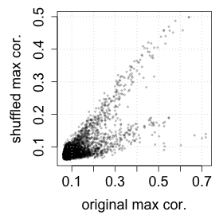

```r
#set diagonals of matrices to zero:
diag(gene_cors_cellCycle$gcor) = 0
diag(gene_cors_cellCycle$r_gcor) = 0

#plot
png("HCT116_cc/figs/wt_shuffled_max.png",width=280,height=280)
par(mar=c(5,5,1,1))
plot(
apply(gene_cors_cellCycle$gcor,1,max),
apply(gene_cors_cellCycle$r_gcor,1,max),
cex=.4, cex.lab=1.5,cex.axis=1.5,
xlab = "original max cor.",
ylab = "shuffled max cor.",
pch=19,
col="#00000030")
grid()
dev.off()
```

an example for how such plot can be interpreted:

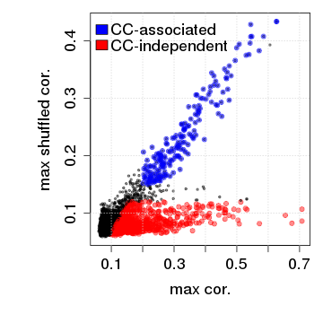

It is apparent that some genes were able to maintain at least one significant correlation, and are therefore display dynamics that are, at least in part, associated with cell-cycle.

Still, it doesn’t mean that all their transcriptional covariation are fully dependent on the cell-cycle.

In order to have a more careful look at the cell-cycle based randomization on gene correlations, we can plot a “chimeric”" matrix (for selected genes, as in this example), comparing the original correlation value in its top triangle, and the shuffled correlation scores in the lower triangle:

an example for how it can look like:

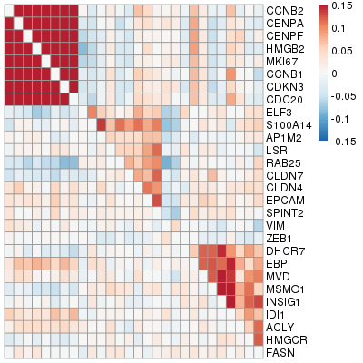

lower triangle: shuffled gene-gene correlations, higher triangle: original gene-gene correlations

In principal, as cell-cycle is after all an evolutionary conserved process, we can try and use the same genes to implement our shuffling strategy in similar biological samples (not promising anything though).

In the following example, we have used the same list of cell-cycle associated genes we obtained from "wild-type HCT-116 cells (the geneSet **hct116_cellCycle**), in order to create a cell-cycle model and implement the randomization strategy on DKO HCT-116 cells, harboring two knockout mutations in DNA-methyltransferases (DNMT1 and DNMT3B):

```r
#download 10x single cell RNA-seq data for DKO
if(!dir.exists("HCT116_cc/10x_HCT116_DKO/")) dir.create("HCT116_cc/10x_HCT116_DKO/")
download.file("http://www.wisdom.weizmann.ac.il/~zoharme/HCT116_umi_tables/DKO/barcodes.tsv","HCT116_cc/10x_HCT116_DKO/barcodes.tsv")
download.file("http://www.wisdom.weizmann.ac.il/~zoharme/HCT116_umi_tables/DKO/genes.tsv","HCT116_cc/10x_HCT116_DKO/genes.tsv")
download.file("http://www.wisdom.weizmann.ac.il/~zoharme/HCT116_umi_tables/DKO/matrix.mtx","HCT116_cc/10x_HCT116_DKO/matrix.mtx")
download.file("http://www.wisdom.weizmann.ac.il/~zoharme/HCT116_umi_tables/DKO/barcodes.tsv","HCT116_cc/10x_HCT116_DKO/tidy_mat.csv")

### 4. download some example figures
if(!dir.exists("HCT116_cc/example_figs/")) dir.create("HCT116_cc/example_figs/")
download.file(url = "http://www.wisdom.weizmann.ac.il/~zoharme/metacell_ccVignette_exampleFigs/HCT116_dko_shuffling_example_matrix.png", destfile = "HCT116_cc/example_figs/HCT116_dko_shuffling_example_matrix.png")
download.file(url = "http://www.wisdom.weizmann.ac.il/~zoharme/metacell_ccVignette_exampleFigs/HCT116_dko_shuffling_example_maximalCorrelations.png", destfile = "HCT116_cc/example_figs/HCT116_dko_shuffling_example_maximalCorrelations.png")
download.file(url = "http://www.wisdom.weizmann.ac.il/~zoharme/metacell_ccVignette_exampleFigs/HCT116_dko_2dproj_ccModel_CCNB1expression.png", destfile = "HCT116_cc/example_figs/HCT116_dko_2dproj_ccModel_CCNB1expression.png")
download.file(url = "http://www.wisdom.weizmann.ac.il/~zoharme/metacell_ccVignette_exampleFigs/HCT116_dko_total_UMI_per_metacells_CCNB1expression.png", destfile = "HCT116_cc/example_figs/HCT116_dko_total_UMI_per_metacells_CCNB1expression.png")

#load DKO UMI matrix
mcell_import_scmat_10x(mat_nm = "mat_dko",
                       base_dir = "HCT116_cc/10x_HCT116_DKO/",
                       force=TRUE)
```

```
#> summing up total of 186 paralog genes into 91 unique genes
#> [1] TRUE
```

```r
#create a DKO expression matrix for cell-cycle geneSet only
mcell_mat_ignore_genes(new_mat_id = "mat_dko_cellCycle", mat_id = "mat_dko",
                                ig_genes = names(scdb_gset("hct116_cellCycle")@gene_set),
                                reverse=T)
```

As an exercise - go ahead and try find cell-cycle independent covariation in HCT116 DKO cells, by using MetaCell package and the methodology described above.

You can check yourself by comparing the output of your analysis to the figures shown below.

GOOD LUCK! zohar.meir@weizmann.ac.il

DKO cell-cycle model:

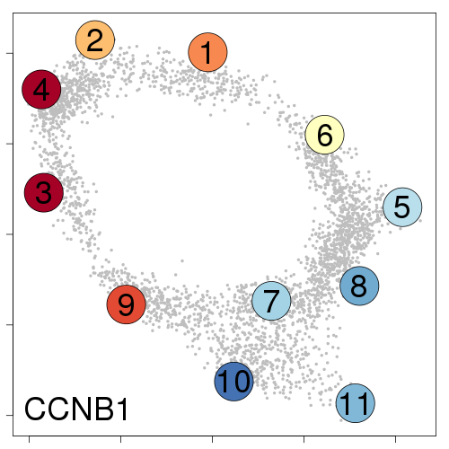

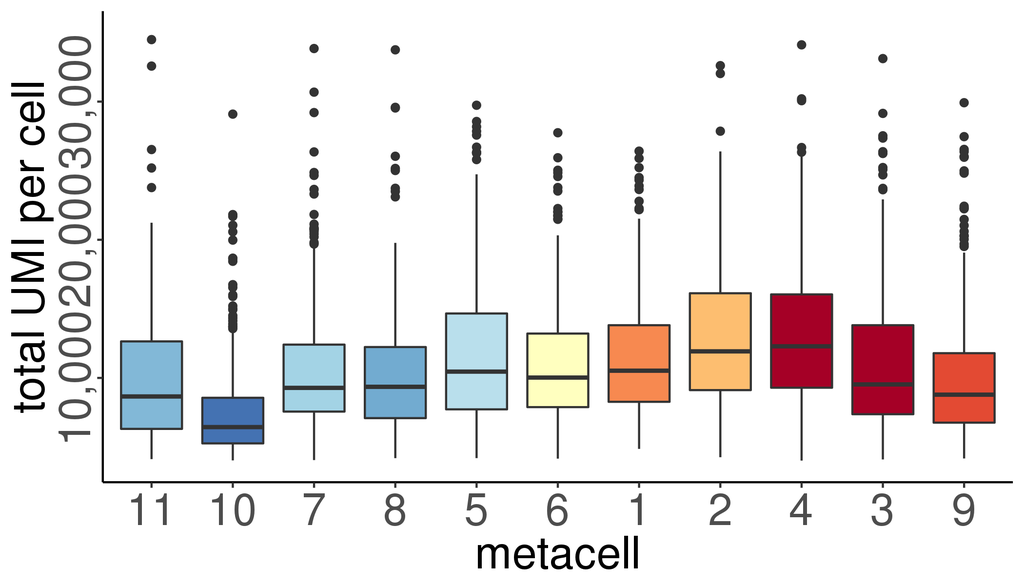

DKO cell-cycle randomization identifies cell-cycle dependenedt and independent transcriptional variance between cells:

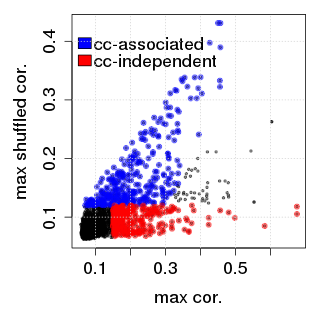

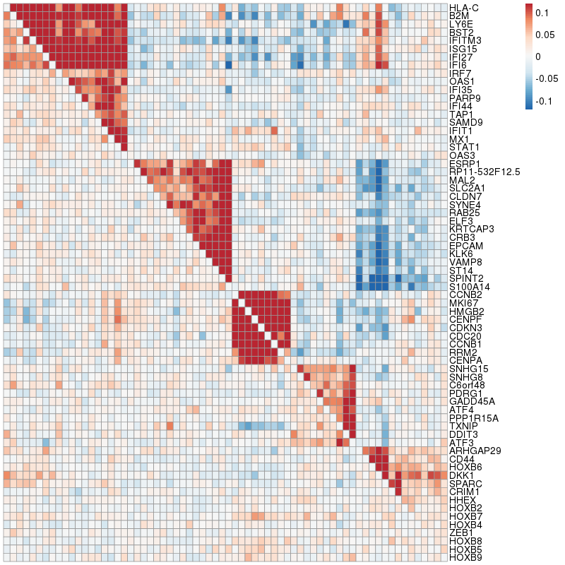